# Earthquakes 2021

Nicholas Jacob

8/19/2021

## Scrapping Wikipedia

First I am going to gather the data from wikipedia with the `rvest` library.

```r
html <- read_html(url)
```

Let’s take a look at the html and see what we have gathered.

```r
html[1]
```

```
## $node
## <pointer: 0x55c40374eb90>
```

Look’s like we got something. Let’s see if we can extract the tables from the webpage.

```r
tables <- html %>%
  html_table(header = TRUE)

length(tables)
```

```
## [1] 25
```

That was a lot of tables! Let’s dig in and see if we can extract the monthly ones. I think the seventh one is January’s.

```r
tables[[7]][-1,]
```

```
## # A tibble: 19 × 8
##    Date   `Country and loc… Mw    `Depth (km)` MMI   Notes Casualties Casualties
##    <chr>  <chr>             <chr> <chr>        <chr> <chr> <chr>      <chr>
##  1 3[1]   United States, A… 6.1   21.0         VI    -     -          -
##  2 6[2]   New Zealand offs… 6.2   37.1         IV    -     -          -
##  3 6[3]   Croatia, Sisak-M… 4.7   10.0         VIII  It w… -          -
##  4 6[5]   Indonesia, Goron… 6.1   148.0        IV    -     -          -
##  5 8[6]   New Zealand offs… 6.3   224.0        IV    -     -          -
##  6 8[7]   Vanuatu, Tafea o… 6.1   113.0        IV    -     -          -
##  7 10[8]  Argentina, Jujuy… 6.1   217.0        IV    -     -          -
##  8 10[9]  Vanuatu, Malampa… 6.1   160.0        IV    -     -          -
##  9 10[10] Turkey, Ankara, … 4.3   10.0         IV    Seve… -          -
## 10 11[12] Mongolia, Khövsg… 6.7   10.0         VIII  The … -          53
## 11 14[15] Indonesia, West … 5.7   18.0         VII   It w… -          1
## 12 14[17] Indonesia, West … 6.2   18.0         VIII  The … 108        3,369
## 13 15[20] Iran, Hormozgan,… 5.5   8.0          VII   Abou… -          1
## 14 19[22] Argentina, San J… 6.4   16.9         VII   Vari… -          14
## 15 21[25] Indonesia offsho… 7.0   80.0         VI    A fe… -          -
## 16 23[27] Spain, Andalusia… 4.2   10.0         IV    It w… -          1
## 17 23[29] Antarctica offsh… 6.9   9.8          V     Smal… -          -
## 18 28[32] Spain, Andalusia… 4.3   10.0         IV    It w… -          -
## 19 31[34] Guyana, Upper Ta… 5.5   5.4          VIII  It w… -          -
```

Let’s now create our eventual final dataframe and make certain we add a column highlighting what month this happened in.

```r
jan <- tables[[7]][-1,]

df <- jan %>% add_column(Month = 'January')
```

```r
monthlist = c('January','February','March','April','May','June','July','August','September')
counter = c(2:9)

for (number in counter){
  newtable <- tables[[5+2*number]][-1,] #the minus one is to get rid of the title of the columns
  newtable <- newtable %>% add_column(Month = monthlist[number])
  df <- bind_rows(df,newtable)
}
```

[output not shown]

```r
head(df)
```

```
## # A tibble: 6 × 9
##   Date  `Country and locatio… Mw    `Depth (km)` MMI   Notes      Casualties...7
##   <chr> <chr>                 <chr> <chr>        <chr> <chr>      <chr>
## 1 3[1]  United States, Alask… 6.1   21.0         VI    -          -
## 2 6[2]  New Zealand offshore… 6.2   37.1         IV    -          -
## 3 6[3]  Croatia, Sisak-Mosla… 4.7   10.0         VIII  It was an… -
## 4 6[5]  Indonesia, Gorontalo… 6.1   148.0        IV    -          -
## 5 8[6]  New Zealand offshore… 6.3   224.0        IV    -          -
## 6 8[7]  Vanuatu, Tafea offsh… 6.1   113.0        IV    -          -
## # … with 2 more variables: Casualties...8 <chr>, Month <chr>
```

I am going to need to do some cleaning now that I have gathered the data. In the *Date* column there is a reference hyperlink in square brackets. Let’s get rid of that and rename it *Day*

```r
df <- df %>%
  mutate(
    Day = str_remove_all(Date,pattern = "\\[*[0-9]*\\]")
  )
```

Next I’d like to change all the casualty entries from *NA* to zero.

```r
df <- df %>%
  mutate(
    Deaths = str_replace_all(Casualties...7,"\\-","0"),
    Injuries = str_replace_all(Casualties...8,"\\-","0")
  )
```

They were not actually `NA` but were `-`. Tricky!

Let’s continue looking to extract some information about country and location

```r
df<- df %>%
  mutate(
    Offshore = str_detect(`Country and location`,"offshore"),
    Country = str_extract(`Country and location`,'[A-z]+')
  )
```

A couple of these are wrong, I’ll fix the obvious ones and come back if I see others I missed later.

```r
df <- df %>%
  mutate(
    Country = replace(Country, Country == 'United','United States'),
    Country = replace(Country, Country == 'South', 'South Georgia'),
    Country = replace(Country, Country == 'Papua','Papua New Guinea')
  )
```

```r
df <- df %>%
  mutate(
    Country = replace(Country, str_detect(`Country and location`,'New Zealand'),'New Zealand'),
    Country = replace(Country, str_detect(`Country and location`,'New Cal'),'New Caledonia')
                 )
```

```r
df <- df %>%
  rename(Depth = 'Depth (km)')
```

Okay I think I have extracted all the info I am going to. I’ll clean up the dataset and organize it.

```r
df <- df %>%
  select(c(Month,Day,Country,Deaths,Injuries,Mw,Depth,MMI,Offshore))
```

```r
df <- df %>%
  mutate(
    Deaths = str_remove_all(Deaths,","),
    Injuries = str_remove_all(Injuries, ",")
  )
```

```r
df <- df %>%
  mutate(Deaths = as.integer(Deaths),
         Injuries = as.integer(Injuries),
         Depth = as.numeric(Depth),
         Day = as.integer(Day),
         Mw = as.numeric(Mw))
```

```r
df <- df %>%
  drop_na()
```

## Ready For EDA

```r
df %>%
  summarize(Average_Deaths = mean(Deaths),
            Average_Injuries = mean(Injuries))
```

```
## # A tibble: 1 × 2
##   Average_Deaths Average_Injuries
##            <dbl>            <dbl>
## 1           15.3             113.
```

```r
df %>% summarize_if(is.numeric, c(Mean = mean,Median = median))
```

```
## # A tibble: 1 × 10
##   Day_Mean Deaths_Mean Injuries_Mean Mw_Mean Depth_Mean Day_Median Deaths_Median
##      <dbl>       <dbl>         <dbl>   <dbl>      <dbl>      <int>         <int>
## 1     14.1        15.3          113.    6.08       41.9         13             0
## # … with 3 more variables: Injuries_Median <int>, Mw_Median <dbl>,
## #   Depth_Median <dbl>
```

```r
library(corrr)
df_cor <- df %>%
  select(c(Day,Injuries,Deaths,Mw,Depth)) %>%
  correlate()
```

```
##
## Correlation method: 'pearson'
## Missing treated using: 'pairwise.complete.obs'
```

```r
df_cor
```

```
## # A tibble: 5 × 6
##   term          Day Injuries   Deaths      Mw   Depth
##   <chr>       <dbl>    <dbl>    <dbl>   <dbl>   <dbl>
## 1 Day      NA        0.00774 -0.00139 -0.0721 -0.149
## 2 Injuries  0.00774 NA        0.976    0.127  -0.0356
## 3 Deaths   -0.00139  0.976   NA        0.128  -0.0309
## 4 Mw       -0.0721   0.127    0.128   NA       0.0882
## 5 Depth    -0.149   -0.0356  -0.0309   0.0882 NA
```

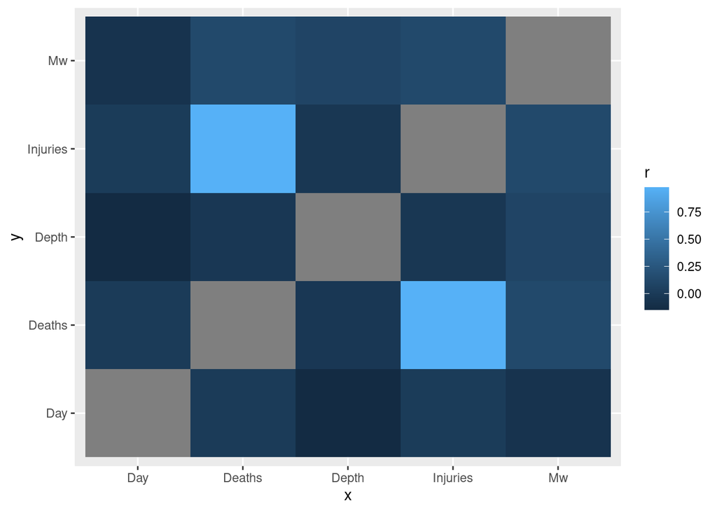

```r
stretch(df_cor) %>%
  ggplot(aes(x=x, y=y, fill=r, label = round(r,2))) +
  geom_tile()
```

```r
df %>%
  group_by(MMI) %>%
  summarize_if(is.numeric,mean)
```

```
## # A tibble: 10 × 6
##    MMI     Day   Deaths Injuries    Mw Depth
##    <chr> <dbl>    <dbl>    <dbl> <dbl> <dbl>
##  1 -     10.9    0         0      6.15  14.3
##  2 I     11      0         0      6.65  10
##  3 II     8.25   0         0.5    5.8  304.
##  4 III   10.8    0.0833    0      6.1   66.0
##  5 IV    14.4    0.0189    0.170  6.09  51.6
##  6 IX    15.5  563.     3198.     6.15  10
##  7 V     15      0.75     10.8    5.88  25.6
##  8 VI    13.7    0.0625    0.25   6.12  22.1
##  9 VII   16.6    0.552    38.8    6.05  24.4
## 10 VIII  13.5    9.69    283.     6.21  14.3
```

```r
summary(df$Day)
```

```
##    Min. 1st Qu.  Median    Mean 3rd Qu.    Max.
##    1.00    7.00   13.00   14.09   21.00   31.00
```

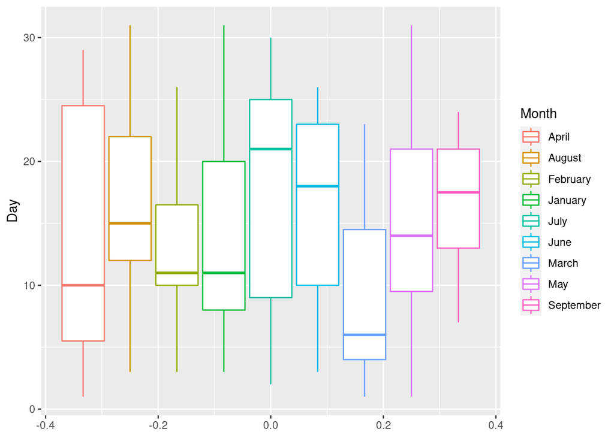

```r
ggplot(data = df, aes(y= Day,color = Month)) +
  geom_boxplot()
```

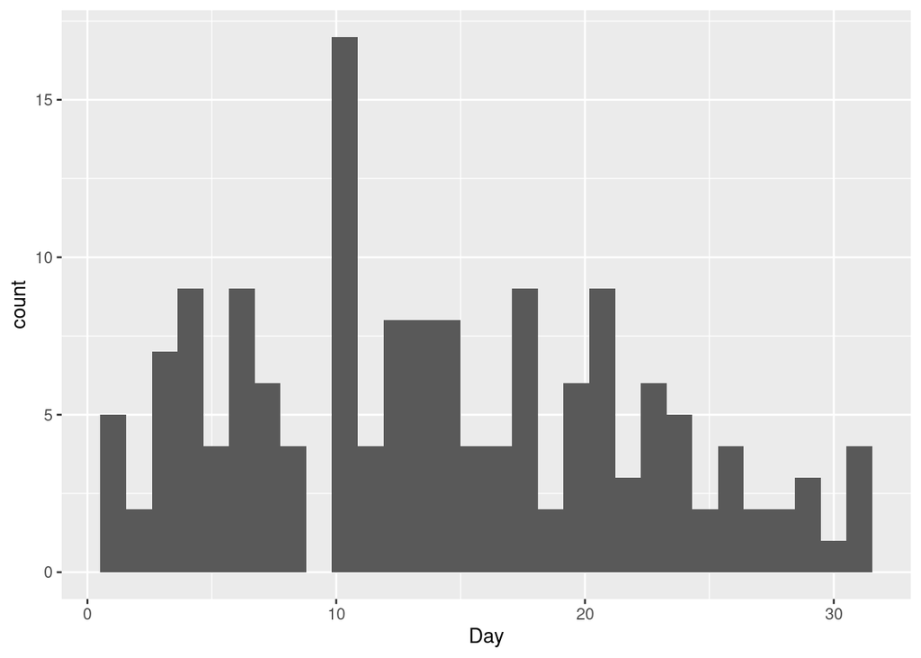

```r
ggplot(df, aes(x= Day)) +
  geom_histogram()
```

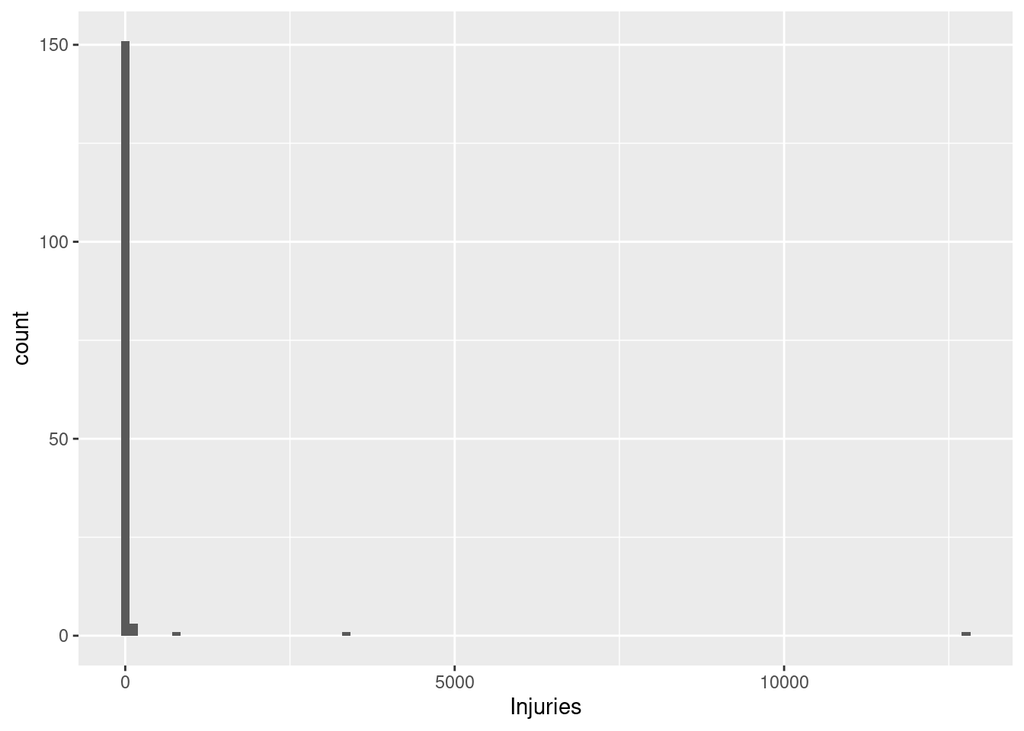

```r
ggplot(df, aes(x= Injuries))+
  geom_histogram(bins = 100)
```

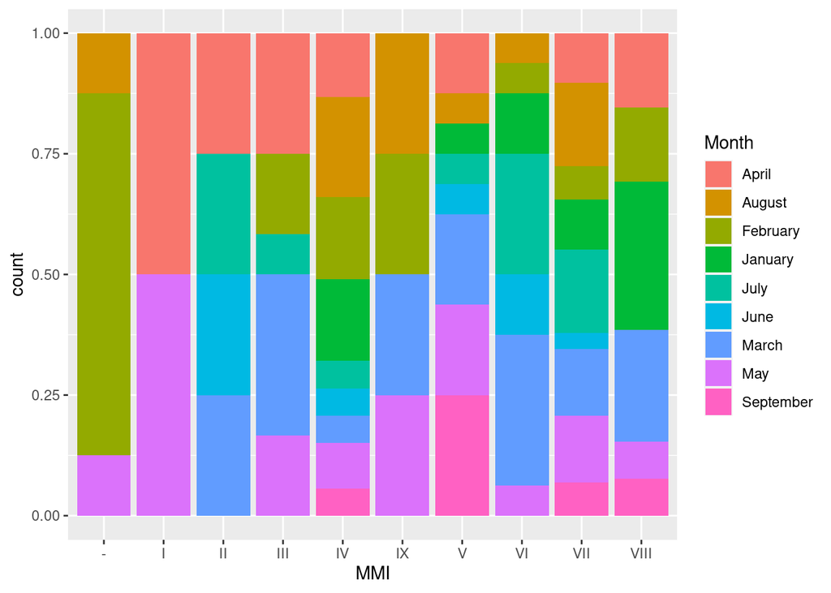

```r
ggplot(df, aes(x= MMI))+
  geom_bar(aes(fill = Month), position = 'fill')
```

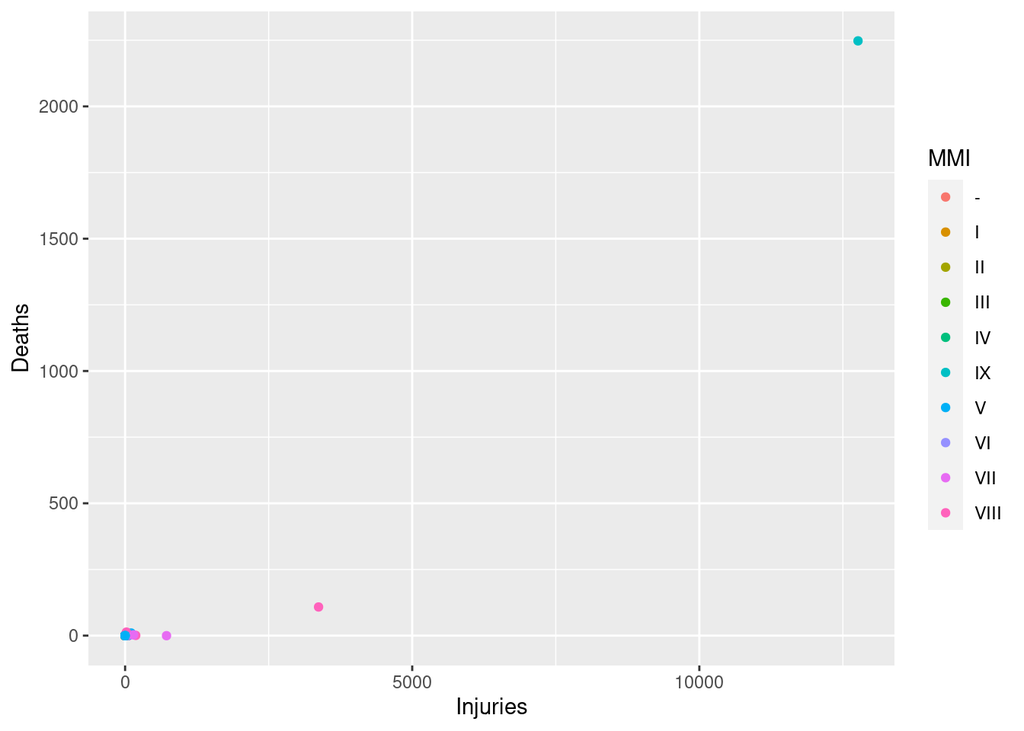

```r
ggplot(df, aes(x= Injuries, y= Deaths)) +
  geom_jitter(aes(color = MMI))
```

```r
library(GGally)
```

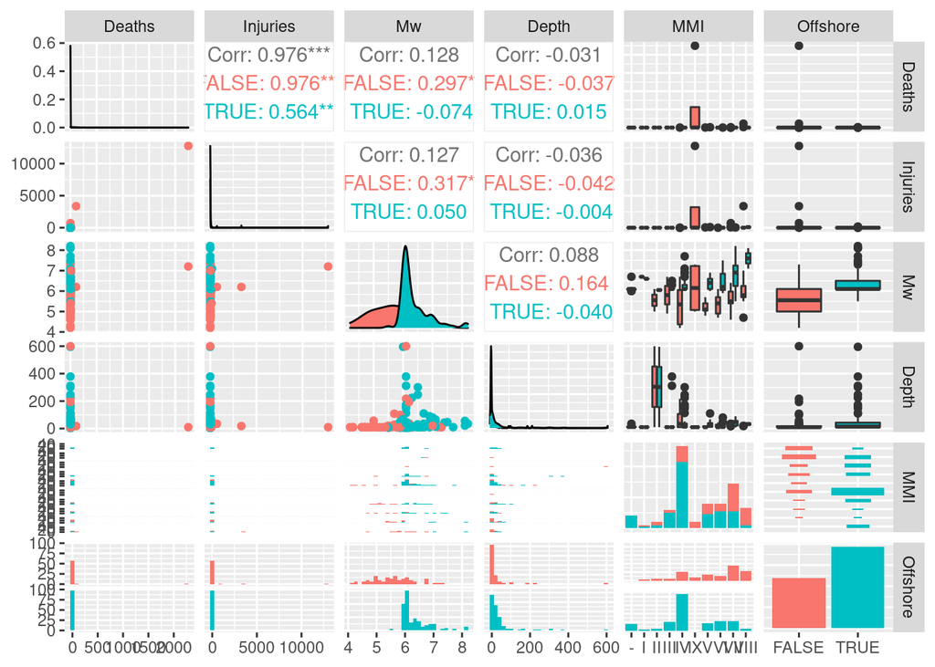

```r
df1 <- df %>%
  select(-Country,-Month,-Day)


ggpairs(df1, aes(color = Offshore))
```

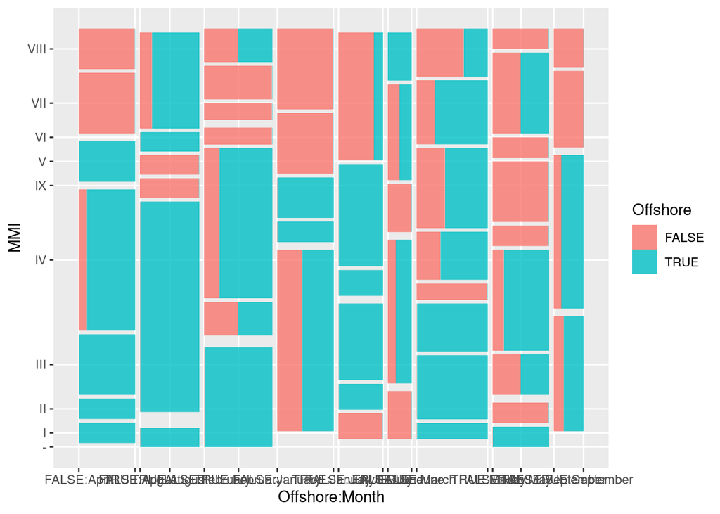

```r
library(ggmosaic)
ggplot(data = df)+
  geom_mosaic( aes(x = product(MMI,Month),fill = Offshore),na.rm = TRUE)
```

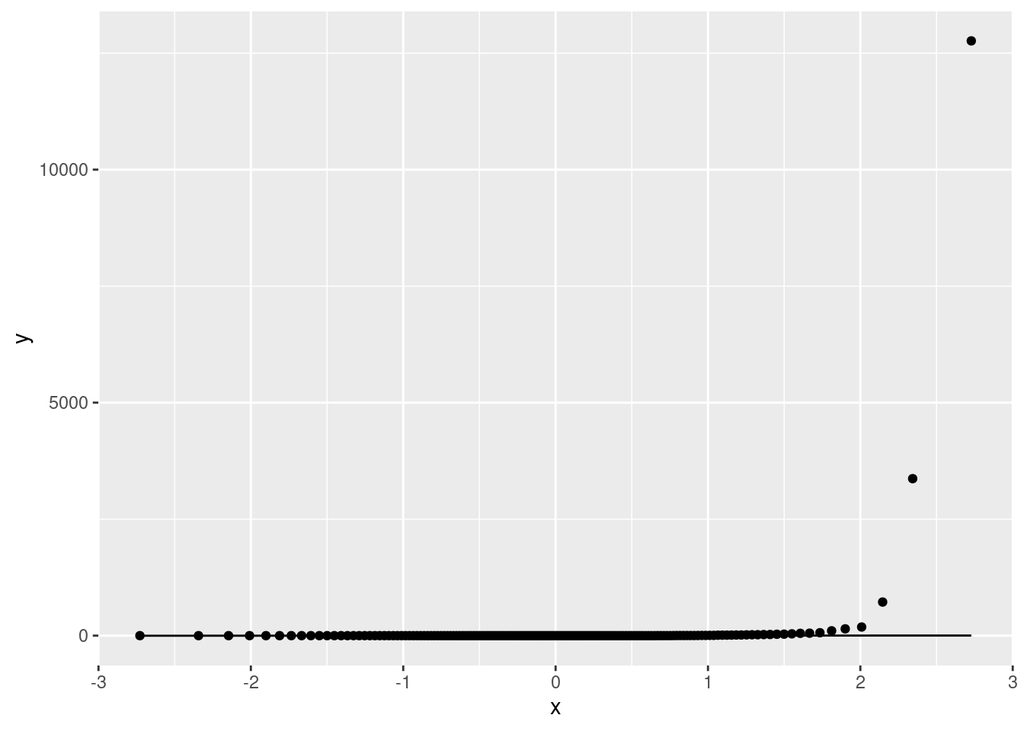

```r
ggplot(df,aes(sample = Injuries)) +
  geom_qq() +
  geom_qq_line()
```

```r
df %>%
  count(Offshore, MMI) %>%
  spread(MMI,n, fill = 0)
```

```
## # A tibble: 2 × 11
##   Offshore   `-`     I    II   III    IV    IX     V    VI   VII  VIII
##   <lgl>    <dbl> <dbl> <dbl> <dbl> <dbl> <dbl> <dbl> <dbl> <dbl> <dbl>
## 1 FALSE        0     1     2     2    10     4     7     5    18    11
## 2 TRUE         8     1     2    10    43     0     9    11    11     2
```

```r
df %>%
  group_by(Offshore) %>%
  summarise(Frequency = n()) %>%
  mutate(Proportion = Frequency/sum(Frequency))
```

```
## # A tibble: 2 × 3
##   Offshore Frequency Proportion
##   <lgl>        <int>      <dbl>
## 1 FALSE           60      0.382
## 2 TRUE            97      0.618
```

## Decision Trees

Moving on to decision trees and classification. The variable you are predicting must be a factor!

```r
df <- df %>% mutate(
  Offshore = factor(Offshore == TRUE, levels = c(TRUE, FALSE),
                    labels = c('offshore','on land' ))
)
```

```r
library(rpart)
library(rpart.plot)

tree <- rpart(Offshore ~.,data = df)
tree
```

```
## n= 157
##
## node), split, n, loss, yval, (yprob)
##       * denotes terminal node
##
## 1) root 157 60 offshore (0.61783439 0.38216561)
##   2) Country=Algeria,Antarctica,Australia,Chile,El,Fiji,France,India,Indonesia,Japan,New Caledonia,New Zealand,Nicaragua,Panama,Papua New Guinea,Philippines,Russia,South Georgia,Tonga,United States,Vanuatu 111 15 offshore (0.86486486 0.13513514)
##     4) Mw>=5.95 100  6 offshore (0.94000000 0.06000000) *
##     5) Mw< 5.95 11  2 on land (0.18181818 0.81818182) *
##   3) Country=Argentina,Armenia,China,Colombia,Croatia,Democratic,Greece,Guyana,Haiti,Iceland,Iran,Iraq,Mauritius,Mexico,Mongolia,Myanmar,Nepal,Peru,Rwanda,Southern,Spain,Taiwan,Tajikistan,Tanzania,Turkey,West 46  1 on land (0.02173913 0.97826087) *
```

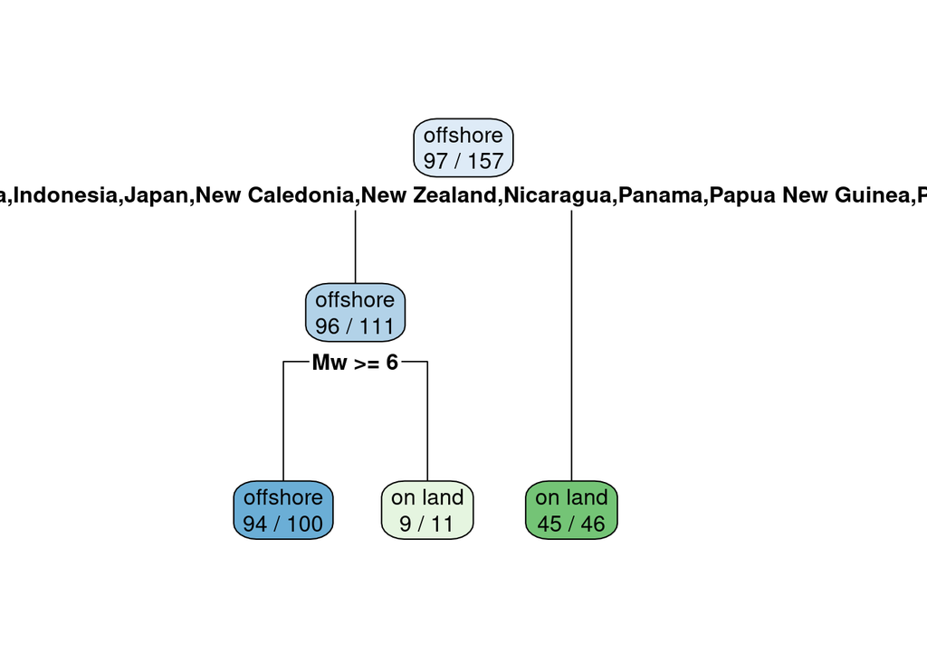

```r
rpart.plot(tree, extra = 2)
```

To make a prediction using the tree we have created, we pass *predict* the tree we have created and the dataset we want it to work on.

```r
pred <- predict(tree, df, type = "class")
head(pred)
```

```
##        1        2        3        4        5        6
## offshore offshore  on land offshore offshore offshore
## Levels: offshore on land
```

Each has been classified into its category. You can also recover the probabilities of the classification by dropping the *type = “class”*

```r
predict(tree, df) %>%
  head()
```

```
##     offshore   on land
## 1 0.94000000 0.0600000
## 2 0.94000000 0.0600000
## 3 0.02173913 0.9782609
## 4 0.94000000 0.0600000
## 5 0.94000000 0.0600000
## 6 0.94000000 0.0600000
```

Confusion table follows by using the classified data.

```r
confusion_table <- with(df, table(Offshore, pred))
confusion_table
```

```
##           pred
## Offshore   offshore on land
##   offshore       94       3
##   on land         6      54
```

I will now examine what happens if I withhold some of the data and do a cross validation. I split the data into thirds for testing and training.

```r
library(caret)
inTrain <- createDataPartition(y = df$Month, p = .66, list = FALSE)
df_train <- df %>% slice(inTrain)
df_test <- df %>% slice(-inTrain)
```

```r
dim(df_train)
```

```
## [1] 108   9
```

```r
dim(df_test)
```

```
## [1] 49  9
```

I will use the training set to build my model and then test it. If you look at my original tree, the country is very important. I am going to remove it from my tree and not allow that to be part of the decision tree (it was causing hell in me creating a tree!).

```r
tree_from_train <- rpart(Offshore ~.,data = subset(df_train, select=c( -Country)))
pred_test <- predict(tree_from_train, subset(df_test, select=c( -Country)), type = "class")
with(df_test, table(Offshore, pred_test))
```

```
##           pred_test
## Offshore   offshore on land
##   offshore       24       2
##   on land         2      21
```

Pretty decent job predicting on the withheld data!

I’ll create a full tree next! I only have ~150 data points so I won’t have to chop it but if you have lots of data please do! I left the code that does chop it *sample_n()* gives *n* samples of the data

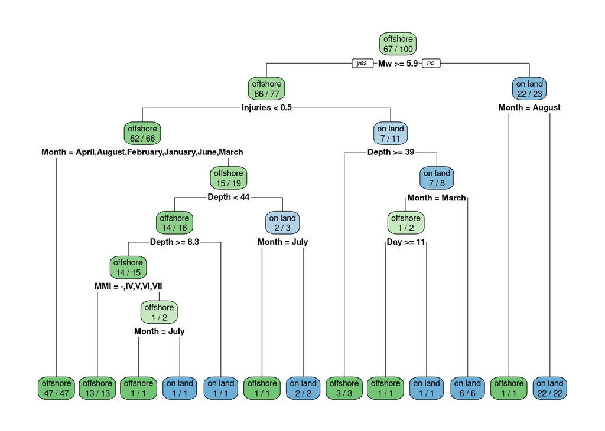

```r
df_no_Country <- subset(df, select=c( -Country))
tree_full <- sample_n(df_no_Country,100) %>% #only keeps 100 of the data points ()
  rpart(Offshore ~., data = ., control = rpart.control(minsplit = 2, cp = 0))

rpart.plot(tree_full, extra = 2, roundint=FALSE,
  box.palette = list( "Gn", "Bu")) # specify 2 colors
```

Holy cow that looks difficult to interpret!

I see now that I was supposed to withhold some data to test with. I don’t have access to that data, but I can do predictions on all the data. Note the 100 above are perfectly classified so the 50 that are left are the only ones that could be mis-classified.

```r
pred_full <- predict(tree_full, df_no_Country, type = "class")
with(df, table(Offshore, pred_full))
```

```
##           pred_full
## Offshore   offshore on land
##   offshore       96       1
##   on land         7      53
```

```r
imp <- varImp(tree)
head(imp)
```

```
##            Overall
## Country  54.025711
## Depth     6.655712
## Injuries 25.842196
## MMI      18.824468
## Month     2.027027
## Mw       49.121808
```

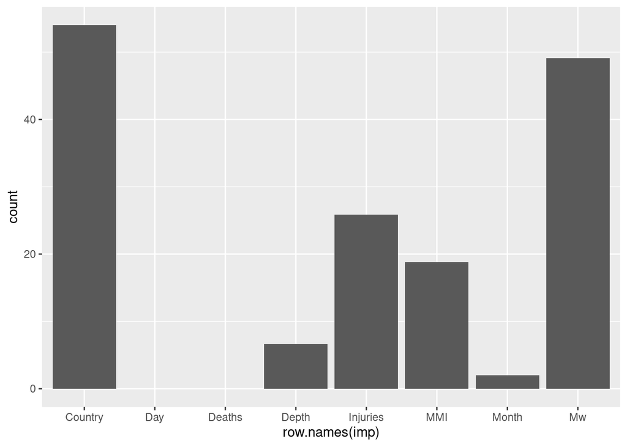

```r
imp %>% ggplot(aes(x = row.names(imp), weight = Overall)) +
  geom_bar()
```

I am not satisfied with this way as I have no idea what *varimp* does, so I’ll repeat this using a chi-squared test for significance.

```r
library(FSelector)

weights <- df %>% chi.squared(Offshore ~ ., data = .) %>%
  as_tibble(rownames = "feature") %>%
  arrange(desc(attr_importance))
weights
```

```
## # A tibble: 8 × 2
##   feature  attr_importance
##   <chr>              <dbl>
## 1 Country            0.862
## 2 Mw                 0.713
## 3 Injuries           0.533
## 4 MMI                0.517
## 5 Month              0.291
## 6 Day                0
## 7 Deaths             0
## 8 Depth              0
```

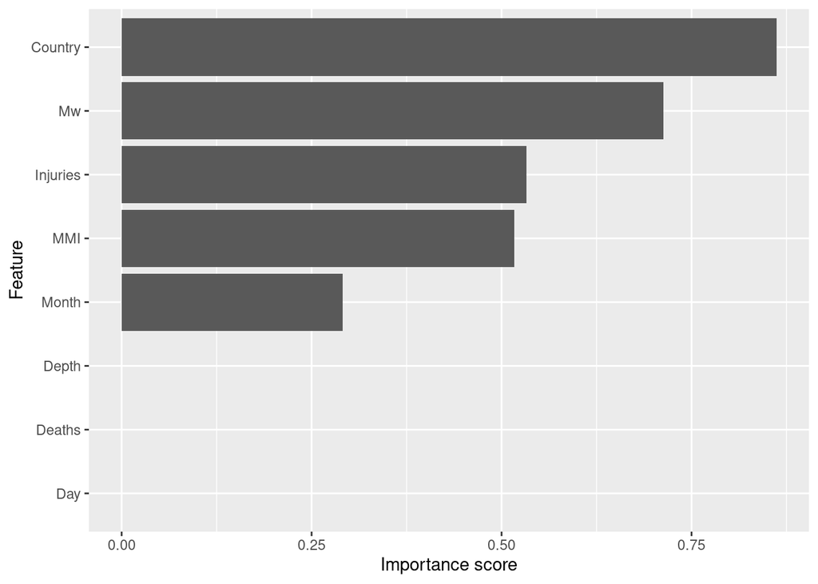

```r
ggplot(weights,
  aes(x = attr_importance, y = reorder(feature, attr_importance))) +
  geom_bar(stat = "identity") +
  xlab("Importance score") + ylab("Feature")
```

Another tree because I was playing around…

```r
tree1 <- rpart(MMI ~Offshore + Deaths + Mw,data = df, method = 'class')
tree1
```

```
## n= 157
##
## node), split, n, loss, yval, (yprob)
##       * denotes terminal node
##
##  1) root 157 104 IV (0.051 0.013 0.025 0.076 0.34 0.025 0.1 0.1 0.18 0.083)
##    2) Offshore=offshore 97  54 IV (0.082 0.01 0.021 0.1 0.44 0 0.093 0.11 0.11 0.021)
##      4) Mw< 6.8 80  41 IV (0.1 0.013 0.025 0.12 0.49 0 0.1 0.1 0.05 0) *
##      5) Mw>=6.8 17  10 VII (0 0 0 0 0.24 0 0.059 0.18 0.41 0.12) *
##    3) Offshore=on land 60  42 VII (0 0.017 0.033 0.033 0.17 0.067 0.12 0.083 0.3 0.18)
##      6) Mw< 5.35 21  16 IV (0 0 0.048 0.048 0.24 0.095 0.24 0.095 0.19 0.048)
##       12) Mw>=4.75 13   8 V (0 0 0.077 0.077 0.077 0.15 0.38 0.077 0.15 0) *
##       13) Mw< 4.75 8   4 IV (0 0 0 0 0.5 0 0 0.13 0.25 0.12) *
##      7) Mw>=5.35 39  25 VII (0 0.026 0.026 0.026 0.13 0.051 0.051 0.077 0.36 0.26)
##       14) Mw>=6.55 7   5 IX (0 0.14 0 0.14 0.14 0.29 0 0 0 0.29) *
##       15) Mw< 6.55 32  18 VII (0 0 0.031 0 0.12 0 0.063 0.094 0.44 0.25) *
```

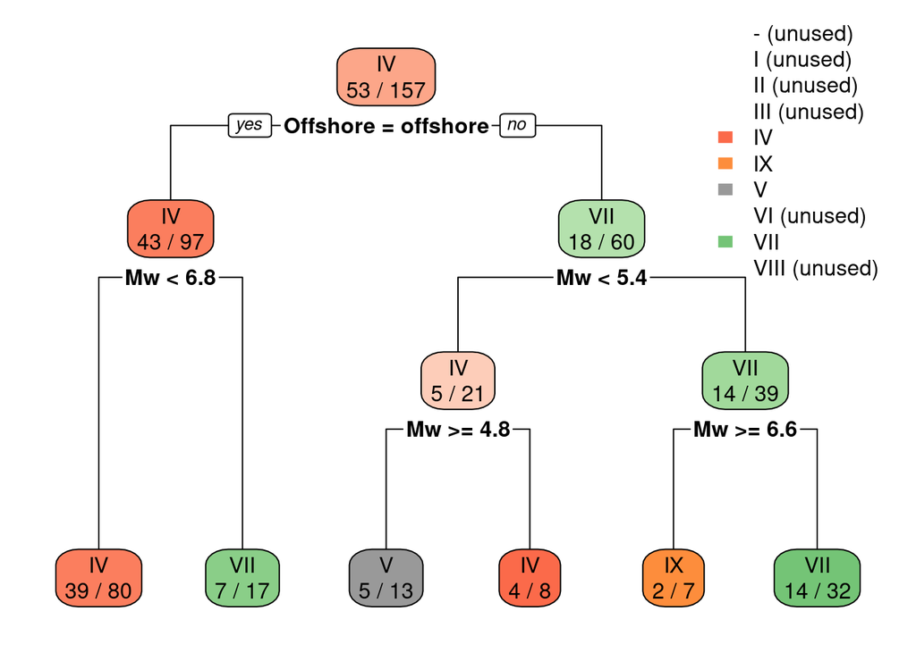

```r
rpart.plot(tree1, extra = 2)
```

If you want to implement C4.5 or C5.0, check out the examples [here](https://rpubs.com/kjmazidi/195428)